# U.S. Demand for Avocados and Conflict in Producing Countries

## Why Avocados

Using data on production volume and import value I am going to investigate how change in demand affects major avocado producing regions.

**For those more interested in visualizations and accompanying analysis than setup and cleaning, please see below:**

Analysis

# Setup

## Importing Modules

```python
import numpy as np
import pandas as pd
import datetime

import matplotlib as mpl
import matplotlib.pyplot as plt
# Formatting Plot axes
import matplotlib.ticker as ticker
import seaborn as sns
```

## Setup for Vizualization

```python
# Set matplotlib to default
mpl.rcParams.update(mpl.rcParamsDefault)

###############################################################
#### Display Settings ####

# Dimensions and color for single plot
X_SIZE = 7
Y_SIZE = 5
SINGLE_PLOT_SIZE = (X_SIZE, Y_SIZE)
SINGLE_PLOT_COLOR = "tab:blue"

# Seaborn Plot Style
sns.set_style('whitegrid')

# Set title size
mpl.rcParams['axes.titlesize'] = 10
# Font for plots
mpl.rcParams['font.family'] = "Bahnschrift"

###############################################################
#### Formatting Functions ####
# Solution found at: https://stackoverflow.com/questions/61330427/set-y-axis-in-millions
def set_tick(num, pos):
    magnitude = 0
    while abs(num) >= 1000:
        magnitude += 1
        num /= 1000.0

    return "%.2f%s" % (num, ["", "K", "M", "B", "T", "P"][magnitude])

formatter = ticker.FuncFormatter(set_tick)

###############################################################
#### Helper Functions ####

# Helper function to reference current state of dataframe
# df will be the current state of the dataframe after manipulation
# var_name then can be used to refernce that
# Solution found at: https://youtu.be/zgbUk90aQ6A
def catch_state(df, var_name):
    globals()[var_name] = df

    return df
```

## Bringing in Data

The United Nations provides extensive information on both production volume and demand for crops. (source: [UN FAO Stat](https://www.fao.org/faostat/en/#data)).

Setting a local file path

```python
data_path = "Data/"
```

```python
# Food Production
food = pd.read_csv(data_path + "Production_Crops_Livestock_E_All_Data.csv", engine = 'python')

# US Import value
value = pd.read_csv(data_path + "Import_Quantity_Value_US_FAOSTAT_data_en_3-20-2023.csv")

# Mexican Agriculture Data
mex = pd.read_csv(data_path + "Mexico_Agriculture_English.csv")

# GDELT Global Conflict Data
# Most of the data from GDELT is categorical, so it will be imported as such to save memory
gdelt = pd.read_csv(data_path + "GDELT.csv",
                    usecols = ["Country", "Name", "Date", "QuadClass", "EventRootCode", "COUNT"],
                    dtype = {"Country" : "category",
                             "Name" : "category",
                             "QuadClass" : "category",
                             "EventRootCode" : "category"},
                    # Pull in date as date time object
                    parse_dates = ["Date"])
```

Before any analysis can be conducted the data will need to be cleaned up a bit. The data is stored in a wide format with each year being represented by a column. There are also some superfluous columns (e.g. Item Code, Item Code CPC, Element Code)

## Cleaning Food Production by Country

```python
food.shape
```

```
(79298, 131)
```

The UN Data has around 80k rows and 131 columns. Though most of the columns are yearly data stored in a wide format.

```python
food.head()
```

|  | Area Code | Area Code (M49) | Area | Item Code | Item Code (CPC) | Item | Element Code | Element | Unit | Y1961 | ... | Y2017 | Y2017F | Y2018 | Y2018F | Y2019 | Y2019F | Y2020 | Y2020F | Y2021 | Y2021F |
| --- | --- | --- | --- | --- | --- | --- | --- | --- | --- | --- | --- | --- | --- | --- | --- | --- | --- | --- | --- | --- | --- |
| 0 | 2 | '004 | Afghanistan | 221 | '01371 | Almonds, in shell | 5312 | Area harvested | ha | NaN | ... | 19793.0 | A | 20053.0 | A | 29203.0 | A | 22134.0 | A | 21685.00 | I |
| 1 | 2 | '004 | Afghanistan | 221 | '01371 | Almonds, in shell | 5419 | Yield | hg/ha | NaN | ... | 13788.0 | A | 17161.0 | A | 13083.0 | A | 17759.0 | A | 18748.00 | E |
| 2 | 2 | '004 | Afghanistan | 221 | '01371 | Almonds, in shell | 5510 | Production | tonnes | NaN | ... | 27291.0 | A | 34413.0 | A | 38205.0 | A | 39307.0 | A | 40655.23 | I |
| 3 | 2 | '004 | Afghanistan | 711 | '01654 | Anise, badian, coriander, cumin, caraway, fenn... | 5312 | Area harvested | ha | NaN | ... | 26160.0 | I | 25220.0 | E | 27387.0 | I | 26255.0 | E | 26287.00 | E |
| 4 | 2 | '004 | Afghanistan | 711 | '01654 | Anise, badian, coriander, cumin, caraway, fenn... | 5419 | Yield | hg/ha | NaN | ... | 6970.0 | E | 7866.0 | E | 6902.0 | E | 7409.0 | E | 7379.00 | E |

5 rows × 131 columns

Several of the columns can be removed immediately as they are not needed for the analysis.

```python
# Dropping unused columns
food.drop(columns = ["Item Code", "Item Code (CPC)", "Element Code"], inplace = True)
```

### Aggregate Region Codes

Also contained in this data set are aggregate regions (e.g. World, Africa). These will be removed as well. The M49 codes used by the UN to identify both countries and regions can be found on wikipedia (source: [M49 Codes](https://en.wikipedia.org/wiki/UN_M49))

```python
# Aggregate Regions
(food.query('`Area Code (M49)` == "\'001" and Element == "Yield"')
    .head())
```

|  | Area Code | Area Code (M49) | Area | Item | Element | Unit | Y1961 | Y1961F | Y1962 | Y1962F | ... | Y2017 | Y2017F | Y2018 | Y2018F | Y2019 | Y2019F | Y2020 | Y2020F | Y2021 | Y2021F |
| --- | --- | --- | --- | --- | --- | --- | --- | --- | --- | --- | --- | --- | --- | --- | --- | --- | --- | --- | --- | --- | --- |
| 61276 | 5000 | '001 | World | Abaca, manila hemp, raw | Yield | hg/ha | 5204.0 | E | 6033.0 | E | ... | 6171.0 | E | 6189.0 | E | 6202.0 | E | 6193.0 | E | 6165.0 | E |
| 61279 | 5000 | '001 | World | Agave fibres, raw, n.e.c. | Yield | hg/ha | 10779.0 | E | 9988.0 | E | ... | 6930.0 | E | 6951.0 | E | 6990.0 | E | 6980.0 | E | 6985.0 | E |
| 61282 | 5000 | '001 | World | Almonds, in shell | Yield | hg/ha | 10298.0 | E | 5797.0 | E | ... | 15967.0 | E | 16205.0 | E | 16613.0 | E | 19059.0 | E | 17491.0 | E |
| 61285 | 5000 | '001 | World | Anise, badian, coriander, cumin, caraway, fenn... | Yield | hg/ha | 6671.0 | E | 6749.0 | E | ... | 10181.0 | E | 10128.0 | E | 10742.0 | E | 11032.0 | E | 11729.0 | E |
| 61288 | 5000 | '001 | World | Apples | Yield | hg/ha | 99059.0 | E | 118880.0 | E | ... | 179817.0 | A | 185163.0 | A | 185746.0 | A | 189202.0 | A | 193156.0 | E |

5 rows × 128 columns

```python
# m49 codes to exclude from the data set
drop_regions = ["'001",
 "'002",
 "'005",
 "'009",
 "'010",
 "'013",
 "'019",
 "'021",
 "'029",
 "'030",
 "'034",
 "'035",
 "'039",
 "'053",
 "'054",
 "'057",
 "'061",
 "'142",
 "'143",
 "'145",
 "'150",
 "'151",
 "'154",
 "'155",
 "'419"]

food = food.query('`Area Code (M49)` not in @drop_regions')
```

There are also aggregated region codes not based on geographical affiliation. These are not displayed on the wikipedia page (e.g. 'Low Income Food Deficit Countries'). Many of these regions have longer names. Querying the data based on length of area reveals possible entries to exclude.

```python
(food.assign(long_name = food.Area.apply(lambda row: len(row) > 25))
    .query('long_name == True')
    ["Area"]
    .unique())
```

```
array(['Bolivia (Plurinational State of)',
       "Democratic People's Republic of Korea",
       'Democratic Republic of the Congo', 'Iran (Islamic Republic of)',
       "Lao People's Democratic Republic",
       'Micronesia (Federated States of)',
       'Saint Vincent and the Grenadines',
       'United Kingdom of Great Britain and Northern Ireland',
       'United Republic of Tanzania',
       'Venezuela (Bolivarian Republic of)',
       'Land Locked Developing Countries',
       'Small Island Developing States',
       'Low Income Food Deficit Countries',
       'Net Food Importing Developing Countries'], dtype=object)
```

```python
agg_area = ["Net Food Importing Developing Countries",
            "Small Island Developing States",
            "Low Income Food Deficit Countries",
            "Land Locked Developing Countries",
            "Least Developed Countries"]

food = food.query('Area not in @agg_area')
```

There are still a few other groupings of countries in the data set that do not represent specific countries

```python
unneeded_regions = ["africa",
                    "america",
                    "asia",
                    "europe"]

# Pull any entries that may have a regional component
# Check row against likely region names return true if any of them are cotained in the current row
(food.assign(mask = food.Area.apply(lambda row: any([x in row.lower() for x in unneeded_regions])))
    .query('mask == True')
    ["Area"]
    .unique())
```

```
array(['Central African Republic', 'South Africa',
       'United States of America', 'Eastern Africa', 'Middle Africa',
       'Northern Africa', 'Southern Africa', 'Western Africa',
       'European Union (27)'], dtype=object)
```

The regional groupings in Africa and Europe will be removed

```python
mask = (food.assign(mask = food.Area.apply(lambda row: any([x in row.lower() for x in unneeded_regions])))
    .query('mask == True')
    # remove US and Central African Republic
    .query('Area != "United States of America" and Area != "Central African Republic"')
    ["Area"]
    .unique())

food = food.query('Area not in @mask')
```

### Year Columns

For each year in the data set there is an accompanying `Flag` column that denotes the source of the figure (official figure from government, estimate, etc). These are unneeded for this analysis and will be excluded.

```python
food.iloc[:5,3:10]
```

|  | Item | Element | Unit | Y1961 | Y1961F | Y1962 | Y1962F |
| --- | --- | --- | --- | --- | --- | --- | --- |
| 0 | Almonds, in shell | Area harvested | ha | NaN | NaN | NaN | NaN |
| 1 | Almonds, in shell | Yield | hg/ha | NaN | NaN | NaN | NaN |
| 2 | Almonds, in shell | Production | tonnes | NaN | NaN | NaN | NaN |
| 3 | Anise, badian, coriander, cumin, caraway, fenn... | Area harvested | ha | NaN | NaN | NaN | NaN |
| 4 | Anise, badian, coriander, cumin, caraway, fenn... | Yield | hg/ha | NaN | NaN | NaN | NaN |

Each flag column follows the same pattern (`Y[YEAR]F`) and can easily be dropped by creating an array containing each of the flag column names.

```python
# Data ranges from 1961 - 2021
mask = [f"Y{x}F" for x in range(1961,2022)]

food = food.drop(columns = mask)

food.iloc[:,3:9].head()
```

|  | Item | Element | Unit | Y1961 | Y1962 | Y1963 |
| --- | --- | --- | --- | --- | --- | --- |
| 0 | Almonds, in shell | Area harvested | ha | NaN | NaN | NaN |
| 1 | Almonds, in shell | Yield | hg/ha | NaN | NaN | NaN |
| 2 | Almonds, in shell | Production | tonnes | NaN | NaN | NaN |
| 3 | Anise, badian, coriander, cumin, caraway, fenn... | Area harvested | ha | NaN | NaN | NaN |
| 4 | Anise, badian, coriander, cumin, caraway, fenn... | Yield | hg/ha | NaN | NaN | NaN |

### Long Format

```python
# Specify columns to pivot
melt_values = [f"Y{x}" for x in range(1961,2022)]

# Convert to long format
food_long = (pd.melt(food, id_vars = ["Area", "Item", "Element", "Unit"],
        value_vars = melt_values,
        var_name = "Year",
        value_name = "Quantity"))

# Convert Year column to numeric values
food_long["Year"] = pd.to_numeric(food_long["Year"].str.replace("Y", ""))
# Combine Element and Unit into single column
food_long["Element"] = food_long["Element"] + food_long["Unit"].apply(lambda row: f" ({row})")

food_long

food_long.head()
```

|  | Area | Item | Element | Unit | Year | Quantity |
| --- | --- | --- | --- | --- | --- | --- |
| 0 | Afghanistan | Almonds, in shell | Area harvested (ha) | ha | 1961 | NaN |
| 1 | Afghanistan | Almonds, in shell | Yield (hg/ha) | hg/ha | 1961 | NaN |
| 2 | Afghanistan | Almonds, in shell | Production (tonnes) | tonnes | 1961 | NaN |
| 3 | Afghanistan | Anise, badian, coriander, cumin, caraway, fenn... | Area harvested (ha) | ha | 1961 | NaN |
| 4 | Afghanistan | Anise, badian, coriander, cumin, caraway, fenn... | Yield (hg/ha) | hg/ha | 1961 | NaN |

Finally, the Element column will be pivoted so each observation shows the values for a single crop, in each country, for each year.

```python
food_long = (food_long.drop(columns=["Unit"])
    .pivot(index = ["Area", "Item", "Year"],
           columns = "Element",
           values = "Quantity")
    .reset_index()
    # Remove element from the Index Column
    .rename_axis(None, axis = 1))

food_long.head()
```

|  | Area | Item | Year | Area harvested (ha) | Laying (1000 Head) | Milk Animals (Head) | Prod Popultn (No) | Producing Animals/Slaughtered (1000 Head) | Producing Animals/Slaughtered (Head) | Production (1000 No) | ... | Stocks (1000 Head) | Stocks (Head) | Stocks (No) | Yield (100mg/An) | Yield (No/An) | Yield (hg) | Yield (hg/An) | Yield (hg/ha) | Yield/Carcass Weight (0.1g/An) | Yield/Carcass Weight (hg/An) |
| --- | --- | --- | --- | --- | --- | --- | --- | --- | --- | --- | --- | --- | --- | --- | --- | --- | --- | --- | --- | --- | --- |
| 0 | Afghanistan | Almonds, in shell | 1961 | NaN | NaN | NaN | NaN | NaN | NaN | NaN | ... | NaN | NaN | NaN | NaN | NaN | NaN | NaN | NaN | NaN | NaN |
| 1 | Afghanistan | Almonds, in shell | 1962 | NaN | NaN | NaN | NaN | NaN | NaN | NaN | ... | NaN | NaN | NaN | NaN | NaN | NaN | NaN | NaN | NaN | NaN |
| 2 | Afghanistan | Almonds, in shell | 1963 | NaN | NaN | NaN | NaN | NaN | NaN | NaN | ... | NaN | NaN | NaN | NaN | NaN | NaN | NaN | NaN | NaN | NaN |
| 3 | Afghanistan | Almonds, in shell | 1964 | NaN | NaN | NaN | NaN | NaN | NaN | NaN | ... | NaN | NaN | NaN | NaN | NaN | NaN | NaN | NaN | NaN | NaN |
| 4 | Afghanistan | Almonds, in shell | 1965 | NaN | NaN | NaN | NaN | NaN | NaN | NaN | ... | NaN | NaN | NaN | NaN | NaN | NaN | NaN | NaN | NaN | NaN |

5 rows × 21 columns

There are a large number of missing values. Some of these correspond to missing data. Many of the missing values correpsond to values thar are not applicable to a given item (e.g. Milk Animals does not apply to Almond production). The values of the most use will be Area Harvested and Tonnes.

```python
food.Element.unique()
```

```
array(['Area harvested', 'Yield', 'Production', 'Stocks',
       'Producing Animals/Slaughtered', 'Laying', 'Yield/Carcass Weight',
       'Milk Animals', 'Prod Popultn'], dtype=object)
```

```python
crops = (food_long[["Area", "Item", "Year", "Area harvested (ha)", "Production (tonnes)"]]
         .dropna())

crops.head()
```

|  | Area | Item | Year | Area harvested (ha) | Production (tonnes) |
| --- | --- | --- | --- | --- | --- |
| 14 | Afghanistan | Almonds, in shell | 1975 | 0.0 | 0.0 |
| 15 | Afghanistan | Almonds, in shell | 1976 | 5900.0 | 9800.0 |
| 16 | Afghanistan | Almonds, in shell | 1977 | 6000.0 | 9000.0 |
| 17 | Afghanistan | Almonds, in shell | 1978 | 6000.0 | 12000.0 |
| 18 | Afghanistan | Almonds, in shell | 1979 | 6000.0 | 10500.0 |

```python
crops.shape
```

```
(566714, 5)
```

The final dataframe is approximately 560k rows and 5 columns.

## Cleaning Import Value and Quantity

```python
value.shape
```

```
(44191, 14)
```

```python
value.head()
```

|  | Domain Code | Domain | Area Code (M49) | Area | Element Code | Element | Item Code (CPC) | Item | Year Code | Year | Unit | Value | Flag | Flag Description |
| --- | --- | --- | --- | --- | --- | --- | --- | --- | --- | --- | --- | --- | --- | --- |
| 0 | TCL | Crops and livestock products | 840 | United States of America | 5610 | Import Quantity | 01929.07 | Abaca, manila hemp, raw | 1961 | 1961 | tonnes | 28505.0 | A | Official figure |
| 1 | TCL | Crops and livestock products | 840 | United States of America | 5610 | Import Quantity | 01929.07 | Abaca, manila hemp, raw | 1962 | 1962 | tonnes | 31592.0 | A | Official figure |
| 2 | TCL | Crops and livestock products | 840 | United States of America | 5610 | Import Quantity | 01929.07 | Abaca, manila hemp, raw | 1963 | 1963 | tonnes | 28476.0 | A | Official figure |
| 3 | TCL | Crops and livestock products | 840 | United States of America | 5610 | Import Quantity | 01929.07 | Abaca, manila hemp, raw | 1964 | 1964 | tonnes | 26721.0 | A | Official figure |
| 4 | TCL | Crops and livestock products | 840 | United States of America | 5610 | Import Quantity | 01929.07 | Abaca, manila hemp, raw | 1965 | 1965 | tonnes | 35293.0 | A | Official figure |

What values are described in the Element and Unit Columns?

```python
(value.Element + value.Unit.apply(lambda row: f" ({row})")).unique()
```

```
array(['Import Quantity (tonnes)', 'Import Value (1000 US$)',
       'Import Quantity (Head)', 'Import Quantity (No)',
       'Import Quantity (1000 Head)'], dtype=object)
```

The two values of interest are Import Quantity (tonnes) and Import Value (1000 US$)

```python
# Combine Element and Unit
value = (value.assign(Element = value.Element + value.Unit.apply(lambda row: f" ({row})"))
    # Pivot to wider
    .pivot(index = ["Item", "Year"],
           columns = "Element",
           values = "Value")
    .reset_index()
    .rename_axis(None, axis = 1)
    # Drop Unneeded columns
    .drop(columns = ["Import Quantity (1000 Head)", "Import Quantity (Head)", "Import Quantity (No)"]))

value.head()
```

|  | Item | Year | Import Quantity (tonnes) | Import Value (1000 US$) |
| --- | --- | --- | --- | --- |
| 0 | Abaca, manila hemp, raw | 1961 | 28505.0 | 11178.0 |
| 1 | Abaca, manila hemp, raw | 1962 | 31592.0 | 8662.0 |
| 2 | Abaca, manila hemp, raw | 1963 | 28476.0 | 8636.0 |
| 3 | Abaca, manila hemp, raw | 1964 | 26721.0 | 9100.0 |
| 4 | Abaca, manila hemp, raw | 1965 | 35293.0 | 11142.0 |

The import value will also be converted to units of single dollars (instead of the 1000s in the data set).

```python
value["Import Value ($)"] = value["Import Value (1000 US$)"] * 1000

value.rename(columns = {"Import Quantity (tonnes)" : "Import Quantity (T)"},
                        inplace = True)
```

There are a number of groups of foods listed in the data set. These are not individule imports but whole groups, and will be removed

```python
(value.assign(nec = value.Item.apply(lambda row: "n.e.c." in row))
    .query('nec == True')
    ["Item"]
    .unique())
```

```
array(['Animal oils and fats n.e.c.', 'Bran of cereals n.e.c.',
       'Cereals n.e.c.', 'Citrus juice, concentrated n.e.c.',
       'Compound feed n.e.c.', 'Crude organic material n.e.c.',
       'Dairy products n.e.c.',
       'Edible roots and tubers with high starch or inulin content, n.e.c., dry',
       'Edible roots and tubers with high starch or inulin content, n.e.c., fresh',
       'Eggs from other birds in shell, fresh, n.e.c.',
       'Essential oils n.e.c.', 'Fat preparations n.e.c.',
       'Fine animal hair, n.e.c.', 'Flour of cereals n.e.c.',
       'Flour of roots and tubers n.e.c.', 'Food preparations n.e.c.',
       'Fruit prepared n.e.c.', 'Juice of citrus fruit n.e.c.',
       'Juice of fruits n.e.c.',
       'Meat of pigeons and other birds n.e.c., fresh, chilled or frozen',
       'Meat prepared n.e.c.',
       'Other berries and fruits of the genus vaccinium n.e.c.',
       'Other citrus fruit, n.e.c.', 'Other fibre crops, raw, n.e.c.',
       'Other forage products, n.e.c.', 'Other fruit n.e.c., dried',
       'Other fruits, n.e.c.', 'Other live animals non food, n.e.c.',
       'Other live animals, n.e.c.',
       'Other meat n.e.c. (excluding mammals), fresh, chilled or frozen',
       'Other nuts (excluding wild edible nuts and groundnuts), in shell, n.e.c.',
       'Other oil of vegetable origin, crude n.e.c.',
       'Other oil seeds, n.e.c.', 'Other pulses n.e.c.',
       'Other stimulant, spice and aromatic crops, n.e.c.',
       'Other tropical fruits, n.e.c.', 'Other vegetables, fresh n.e.c.',
       'Sugar and syrups n.e.c.', 'Vegetable products for feed n.e.c.',
       'Vegetable products, fresh or dry n.e.c.'], dtype=object)
```

```python
value = (value.assign(nec = value.Item.apply(lambda row: "n.e.c." in row))
    .query('nec != True')
    .drop(columns = ["nec"]))
```

### Cleaning GDELT

Records of events from GDELT are mostly stored as individual tsv files for a single day. Getting data between 1990 and 2021 required downloading and parsing around 3000 individual files. An in depth examination of that process will be a separate breakdown.

```python
gdelt.head()
```

|  | QuadClass | EventRootCode | COUNT | Date | Country | Name |
| --- | --- | --- | --- | --- | --- | --- |
| 0 | 1 | 03 | 2 | 1990-01-01 | Côte d'Ivoire | Lacs |
| 1 | 1 | 04 | 2 | 1990-01-01 | Côte d'Ivoire | Lacs |
| 2 | 1 | 05 | 5 | 1990-01-01 | Côte d'Ivoire | Lacs |
| 3 | 1 | 01 | 1 | 1990-02-01 | Côte d'Ivoire | Lacs |
| 4 | 1 | 02 | 1 | 1990-02-01 | Côte d'Ivoire | Lacs |

```python
gdelt.shape
```

```
(436188, 6)
```

```python
(gdelt.query('Country == "Mexico"')
    .shape)
```

```
(123727, 6)
```

There are approximately 430k observations in the data set, 120k of those being from Mexico.

GDELT encodes information about events using a system called CAMEO. The numbers represent a set of types of events. For example 01 : Make Public Statement includes 013: Make Optimistic Comment and 014: Consider Policy Option.

```python
# What the Root Codes Mean
codes = {'01': 'Make Public Statement',
 '02': 'Appeal',
 '03': 'Express Intent To Cooperate',
 '04': 'Consult',
 '05': 'Engage In Diplomatic Cooperation',
 '06': 'Engage In Material Cooperation',
 '07': 'Provide Aid',
 '08': 'Yield',
 '09': 'Investigate',
 '10': 'Demand',
 '11': 'Disapprove',
 '12': 'Reject',
 '13': 'Threaten',
 '14': 'Protest',
 '15': 'Exhibit Force Posture',
 '16': 'Reduce Relations',
 '17': 'Coerce',
 '18': 'Assault',
 '19': 'Fight',
 '20': 'Use Unconventional Mass Violence',
 '--' : "Other"}

gdelt["EventRoot_Eng"] = gdelt.EventRootCode.apply(lambda row: codes[row])
gdelt.head()
```

|  | QuadClass | EventRootCode | COUNT | Date | Country | Name | EventRoot_Eng |
| --- | --- | --- | --- | --- | --- | --- | --- |
| 0 | 1 | 03 | 2 | 1990-01-01 | Côte d'Ivoire | Lacs | Express Intent To Cooperate |
| 1 | 1 | 04 | 2 | 1990-01-01 | Côte d'Ivoire | Lacs | Consult |
| 2 | 1 | 05 | 5 | 1990-01-01 | Côte d'Ivoire | Lacs | Engage In Diplomatic Cooperation |
| 3 | 1 | 01 | 1 | 1990-02-01 | Côte d'Ivoire | Lacs | Make Public Statement |
| 4 | 1 | 02 | 1 | 1990-02-01 | Côte d'Ivoire | Lacs | Appeal |

```python
quad_code = {"1" : "Verbal Cooperation",
 "2" : "Material Cooperation",
 "3" : "Verbal Conflict",
 "4" : "Material Conflict"}

gdelt["QuadClass_Eng"] = gdelt.QuadClass.apply(lambda row: quad_code[row])

gdelt.head()
```

|  | QuadClass | EventRootCode | COUNT | Date | Country | Name | EventRoot_Eng | QuadClass_Eng |
| --- | --- | --- | --- | --- | --- | --- | --- | --- |
| 0 | 1 | 03 | 2 | 1990-01-01 | Côte d'Ivoire | Lacs | Express Intent To Cooperate | Verbal Cooperation |
| 1 | 1 | 04 | 2 | 1990-01-01 | Côte d'Ivoire | Lacs | Consult | Verbal Cooperation |
| 2 | 1 | 05 | 5 | 1990-01-01 | Côte d'Ivoire | Lacs | Engage In Diplomatic Cooperation | Verbal Cooperation |
| 3 | 1 | 01 | 1 | 1990-02-01 | Côte d'Ivoire | Lacs | Make Public Statement | Verbal Cooperation |
| 4 | 1 | 02 | 1 | 1990-02-01 | Côte d'Ivoire | Lacs | Appeal | Verbal Cooperation |

## Analysis

First, has demand for avocados increased more relative to other crops the US imports? Import value, which represents the total amount dollars imported for a given year, will be used as a metric for demand.

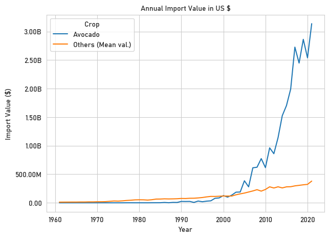

```python
fig, ax = plt.subplots(figsize = SINGLE_PLOT_SIZE)
# Set Y axis format
ax.yaxis.set_major_formatter(formatter)

(value.assign(Crop = np.where(value.Item == "Avocados", "Avocado", "Others (Mean val.)"))
    .groupby(["Year", "Crop"])
    .agg('mean')
    .reset_index()
    .pipe((sns.lineplot, 'data'), x = "Year", y = "Import Value ($)",
          hue = "Crop")
)

ax.set_title("Annual Import Value in US $")

plt.show()
```

This plost shows the total annual import value of avocaods vs. the mean import value for all other crops in the data set. Clearly Avocados have seen a meteoric rise in the value relative to the rest of the crops that the US imports. The next question is where are Avocados primarily grown?

### Where are Avocados Grown?

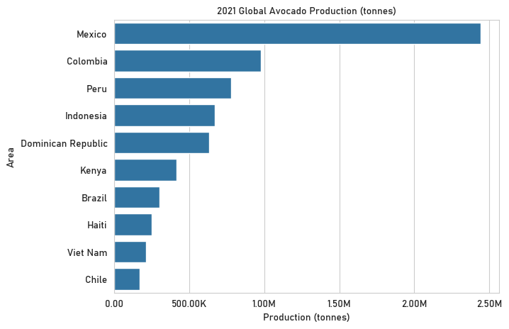

```python
fig, ax = plt.subplots(figsize = SINGLE_PLOT_SIZE)
# Set X axis format
ax.xaxis.set_major_formatter(formatter)

(crops.query('Item == "Avocados" and Year == 2021')
    .sort_values(by = ["Production (tonnes)"], ascending = False)
    # Grab top 10 Producers
    .iloc[0:10,:]
    .pipe((sns.barplot, 'data'), y = "Area", x = "Production (tonnes)",
          color = SINGLE_PLOT_COLOR)
)

ax.set_title("2021 Global Avocado Production (tonnes)")

plt.show()
```

Mexico is the dominant producer of avocados globally accounting for a large portion of total production.

```python
# Mexican Avocado production in 2021
(crops.query('Area == "Mexico" and Item == "Avocados" and Year == 2021')["Production (tonnes)"] /
 # Total Avocado Production in 2021
 crops.query('Item == "Avocados" and Year == 2021').dropna().agg('sum')["Production (tonnes)"]).iloc[0]
```

```
0.2799046164736056
```

In fact, Mexico alone accounted for over almost 28% of global avocado production in 2021.

### Where in Mexico?

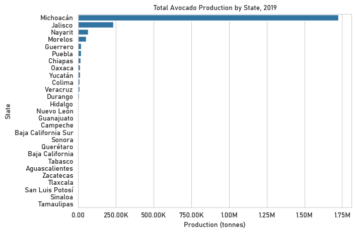

```python
fig, ax = plt.subplots(figsize = SINGLE_PLOT_SIZE)
ax.xaxis.set_major_formatter(formatter)

# 2019 Production of Avocados
(mex.query('Year == 2019 and Crop_Name == "Avocado"')
    # Total production by State (sum of municipalities)
    .groupby(["State"])
    .agg('sum')
    .sort_values(by = "Production_Volume", ascending = False)
    .reset_index()
    .pipe((sns.barplot, 'data'), x = "Production_Volume", y = "State",
          color = SINGLE_PLOT_COLOR));
ax.set_title("Total Avocado Production by State, 2019")
ax.set(xlabel = "Production (tonnes)")

plt.show()
```

Michoacán is the dominate grower of avocados in Mexico producing a vast majority.

### Land Dedicated to Avocado Production

```python
# Pulling the top 100 Crops by tonnage in 2019
mex_top_crops = (mex.query('Year == 2019')
    .groupby(["Crop_Name_Eng"])
    .agg('sum')
    .sort_values(by = "Production_Volume", ascending = False)
    .head(100)
    .reset_index()
    ["Crop_Name_Eng"]
    .unique())
```

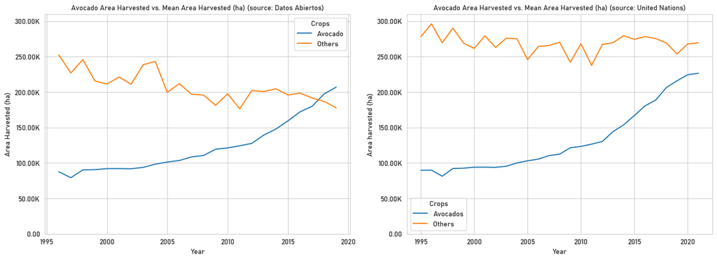

```python
fig, ax = plt.subplots(ncols = 2,
                       figsize = (2 * X_SIZE, Y_SIZE),
                       constrained_layout = True)
# Fromat numbers for y ticks
ax[0].yaxis.set_major_formatter(formatter)
ax[1].yaxis.set_major_formatter(formatter)

# Plotting the mean area harvested for the 2019 top 100 crops by tonnage in Mexico
(mex.query('Crop_Name_Eng in @mex_top_crops and Year <= 2019')
    .groupby(["Year", "Crop_Name"])
    # Sum total area for all of Mexico by each crop for each year
    .agg('sum')
    .reset_index()
    # Pipe aggregated df into helper function
    .pipe(catch_state, var_name = "df2")
    # reference new data frame for if/else grouping (avocado vs. others)
    .assign(Crops = np.where(df2.Crop_Name == "Avocado", "Avocado", "Others"))
    # Group by avocado vs. others
    .groupby(["Year", "Crops"])
    # Find mean area harvested for Avocados vs. Others
    .agg('mean')
    .reset_index()
    .pipe((sns.lineplot, 'data'), x = "Year", y = "Area_Harvested",
          hue = "Crops",
          ax = ax[0])
)

# Create one vs. others column
(crops.assign(Crops = np.where(crops.Item == "Avocados", "Avocados", "Others"))
    .query('Area == "Mexico" and Year >= 1995')
    # Find mean area of Avocados vs. Other crops
    .groupby(["Year", "Crops"])
    .agg('mean')
    .pipe((sns.lineplot, 'data'), x = "Year", y = "Area harvested (ha)",
          hue = "Crops",
          ax = ax[1])
)

# Set Labels for Mexican data
ax[0].set_title("Avocado Area Harvested vs. Mean Area Harvested (ha) (source: Datos Abiertos)")
ax[0].set(ylabel = "Area Harvested (ha)")
ax[0].set_ylim([0,310000])

# Set Labels for UN data
ax[1].set_title("Avocado Area Harvested vs. Mean Area Harvested (ha) (source: United Nations)")
ax[1].set_ylim([0,310000])
plt.show()
```

The mean for the top 100 crops by tonnage was used for the data from the Mexican government. The top crops from 2019 were used instead of 2020 because there was a sharp reduction in the number of unique crops included in the dataset in 2020.

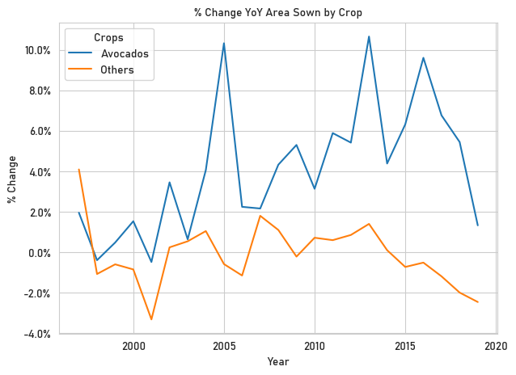

```python
fig, ax = plt.subplots(figsize = SINGLE_PLOT_SIZE)

(mex.assign(Crops = np.where(mex.Crop_Name == "Avocado", "Avocados", "Others"))
    .query('Crop_Name_Eng in @mex_top_crops and Year <= 2019')
    # Find total area for Avocados and all other crops
    .groupby(["Year", "Crops"])
    .agg('sum')
    .reset_index()
    # Pivot to wide with one column for Avocados and one column for others
    .pivot(index = ["Year"],
           columns = "Crops",
           values = "Area_Sown")
    # Calculate percent change
    .pct_change()
    # drop leading years with undefined values
    .dropna()
    .reset_index()
    # pivot back to long so crop type can be used for hue argument
    .melt(id_vars = "Year",
          value_vars = ["Avocados", "Others"],
          value_name = "% Change")
    .pipe((sns.lineplot, 'data'), x = "Year", y = "% Change",
          hue = "Crops",
          ax = ax)
)

ax.yaxis.set_major_formatter(ticker.PercentFormatter(xmax = 1.0))

ax.set_title("% Change YoY Area Sown by Crop")

plt.rc('axes', unicode_minus = False)
plt.show()
```

Looking at year over year change at total area sown for avocados vs. all other crops also suggests that overall cropland is decreasing, but land sown for avocados is continuing to increase.

### GDELT

GDELT is a massive database updated daily that contains records on events that appear in news sources (online, print, tv, etc). GDELT encodes information about events using a system called **Conflict and Mediation Event Observations** (CAMEO). Broadly, each of the 20 parent CAMEO “verbs” fall into one of four categories:

- 1 : Verbal Cooperation
- 2 : Material Cooperation
- 3 : Verbal Conflict
- 4 : Material Conflict

The plot below shows the 20 verbs color coded by their corresponding Quad Class.

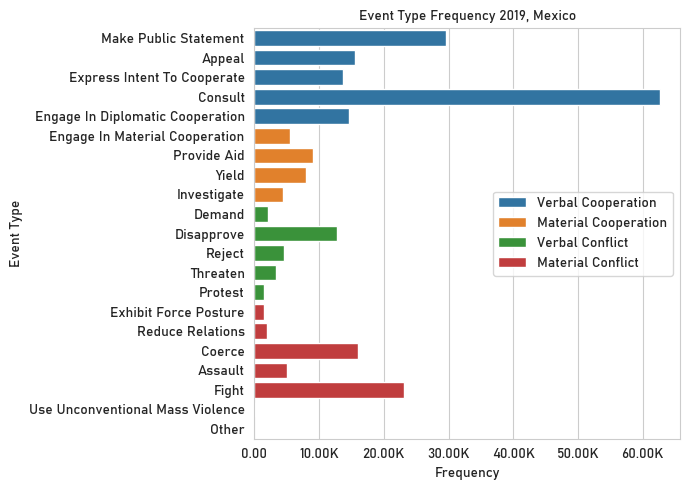

```python
fig, ax = plt.subplots(figsize = SINGLE_PLOT_SIZE,
                       tight_layout = True)
ax.xaxis.set_major_formatter(formatter)

(gdelt.query('Date.dt.year == 2019 and Country == "Mexico"')
    # Group by both quad class
    .groupby(["QuadClass_Eng", "EventRoot_Eng"])
    .agg('sum')
    .reset_index()
    .pipe((sns.barplot, 'data'), x = "COUNT", y = "EventRoot_Eng",
          hue = "QuadClass_Eng",
          dodge = False,
          ax = ax)
)

ax.set_title("Event Type Frequency 2019, Mexico")
ax.set(ylabel = "Event Type",
       xlabel = "Frequency")
ax.legend(loc = "center right")

plt.show()
```

#### Event Frequency in Mexico

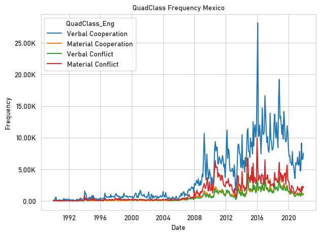

```python
fig, ax = plt.subplots(figsize = SINGLE_PLOT_SIZE)
ax.yaxis.set_major_formatter(formatter)

(gdelt.query('Country == "Mexico"')
    .groupby(["Date", "QuadClass_Eng"])
    .agg('sum')
    .reset_index()
    .pipe((sns.lineplot, 'data'), x = "Date", y = "COUNT",
          hue = "QuadClass_Eng"))

ax.set(ylabel = "Frequency")
ax.set_title("QuadClass Frequency Mexico")

plt.show()
```

Around 2008 all four classes begin trending upward. Now, it's important to remember that this upward trend doesn’t necessarily mean that Mexico suddenly started becoming more active as a country around 2008. Other possible reasons include:

- More media attention paid to Mexico
- Better Spanish language parsing from GDELT
- More media coverage of all events in general

#### Import Value and Event Frequncy

Event frequency for an entire country is going to be incredibly noisy. It has a myriad of contributing factors, many having nothing to do with avocado production. In an attempt to reduce some of this noise, event frequency is going to be limited to the main production region in Mexico: Michoacán.

```python
# Merge Import value and GDELT
gdelt_import_value = (gdelt.query('Country == "Mexico" and Name == "Michoacán"')
    # Aggrgate QuadClass
    .groupby([gdelt["Date"].dt.year, "QuadClass", "QuadClass_Eng"])
    .agg('sum')
    .reset_index()
    .rename(columns = {"Date" : "Year"})
    .merge(value[value.Item == "Avocados"],
          on = "Year",
          how = 'outer')
    .sort_values(by = ["Year"], ascending = False)
    .dropna()
)
```

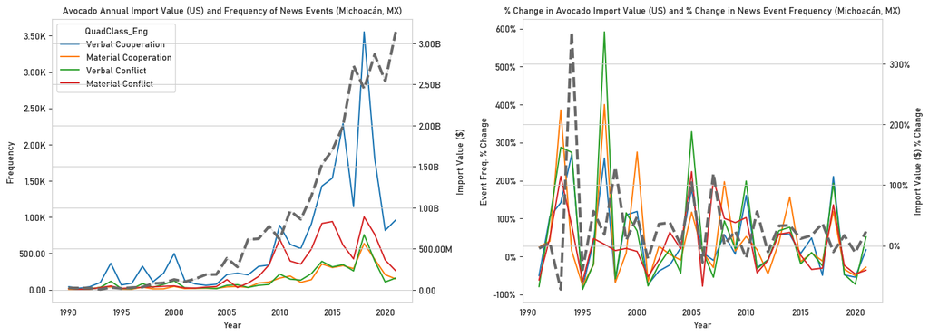

```python
# loose the grid to declutter graph

# Left Plot showing Import value and Event Frequency over time
fig, ax = plt.subplots(ncols = 2,
                       figsize = (2 * X_SIZE, Y_SIZE),
                       constrained_layout = True)

ax[0].yaxis.set_major_formatter(formatter)

# First plot of dual axis -- Event Frequency
sns.lineplot(x = "Year", y = "COUNT",
             hue = "QuadClass_Eng",
             data = gdelt_import_value,
             ax = ax[0])
ax[0].set(ylabel = "Frequency")
ax[0].set_title("Avocado Annual Import Value (US) and Frequency of News Events (Michoacán, MX)")
ax[0].grid(False)

# Second plot of dual axis -- Import Value
ax_0_value = ax[0].twinx()
ax_0_value.yaxis.set_major_formatter(formatter)
sns.lineplot(x = "Year", y = "Import Value ($)",
             data = gdelt_import_value,
             linestyle = '--',
             linewidth = 3.0,
             color = 'dimgray',
             ax = ax_0_value)

# Right Plot showing Year over Year Change
# First axis of dual axis plot -- Event Frequncy
# Note this is not using the Quadclass names, to preserve the legend colors between the plots
(gdelt_import_value.astype({"QuadClass" : "object"}) # Changing QuadClass to string for calculations
    # Agg by year and class
    .groupby(["Year", "QuadClass"])
    # Total events by group
    .agg('sum')
    .reset_index()
    # Pivot QuadClass columns by year
    .pivot(index = "Year",
           columns = "QuadClass",
           values = "COUNT")
    # calculate percent change for each class
    .pct_change()
    .dropna()
    # Get rid of axis name from pivot
    .rename_axis(None, axis = 1)
    .reset_index()
    # Pivot back to long for plotting
    .melt(id_vars = "Year",
          var_name = "QuadClass",
          value_name = "Event Freq. % Change")
    .pipe((sns.lineplot, 'data'), x = "Year", y = "Event Freq. % Change",
          hue = "QuadClass",
          ax = ax[1])
)
ax[1].yaxis.set_major_formatter(ticker.PercentFormatter(xmax = 1.0))
ax[1].set_title("% Change in Avocado Import Value (US) and % Change in News Event Frequency (Michoacán, MX)")
ax[1].grid(False)
ax[1].get_legend().remove()

# Second axis of dual axis plot -- Import Value
ax_1_value = ax[1].twinx()
# Drop duplicated rows
(gdelt_import_value.loc[~gdelt_import_value.duplicated(subset = ["Year", "Import Value ($)"])]
 .sort_values(by = "Year")
 .set_index("Year")
 ["Import Value ($)"]
 .pct_change()
 .reset_index()
 .dropna()
 .pipe((sns.lineplot, 'data'), x = "Year", y = "Import Value ($)",
       linestyle = '--',
       linewidth =  3.0,
       color = 'dimgray',
       # Set to second plot axis
       ax = ax_1_value))
ax_1_value.set(ylabel = "Import Value ($) % Change")
ax_1_value.yaxis.set_major_formatter(ticker.PercentFormatter(xmax = 1.0))

plt.rc('axes', unicode_minus = False)
plt.show()
```

That long chunk of code gives us two views of the relation between avocado import value and events in Michoacán. On the left plot verbal cooperation has always been higher than the rest of the classes however around 2005 Material Violence starts to rise in relation to the other classes.

The year over year change (right plot) is a little hard to interpret because of all of the fluctuation. None of the event types seem to have a markedly different trajectory in terms of their rate of change.

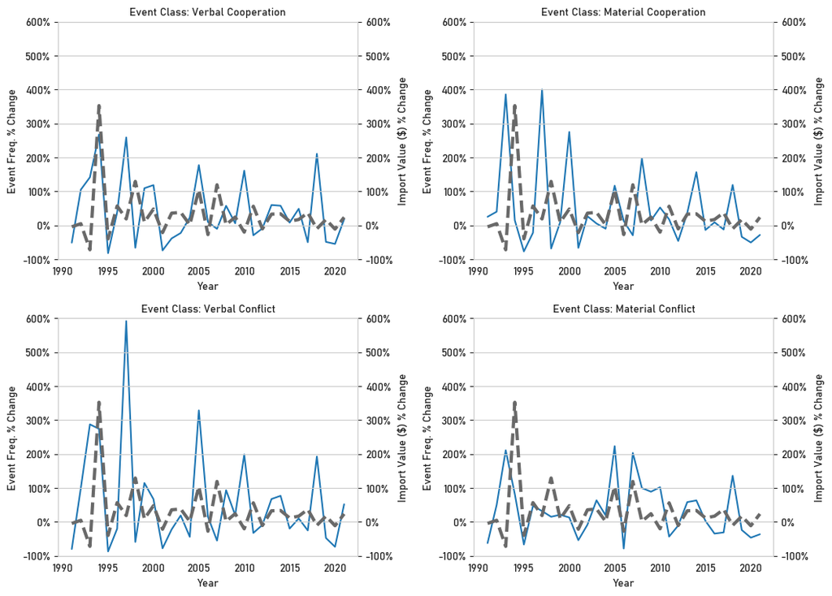

```python
fig, ax = plt.subplots(nrows = 2,
                       ncols= 2,
                       figsize = (X_SIZE * 1.5, Y_SIZE * 1.5),
                       constrained_layout = True)

def quad_class_isolated(quad_class, ax):

      (gdelt_import_value.astype({"QuadClass_Eng" : "object"})
      .query('QuadClass_Eng == @quad_class')
      .groupby(["Year", "QuadClass_Eng"])
      .agg('sum')
      .reset_index()
      .pivot(index = "Year",
            columns = "QuadClass_Eng",
            values = "COUNT")
      .pct_change()
      .dropna()
      .rename_axis(None, axis = 1)
      .reset_index()
      .melt(id_vars = "Year",
            var_name = "QuadClass_Eng",
            value_name = "Event Freq. % Change")
      .pipe((sns.lineplot, 'data'), x = "Year", y = "Event Freq. % Change",
            color = "tab:blue",
            ax = ax)
      )
      ax.yaxis.set_major_formatter(ticker.PercentFormatter(xmax = 1.0))
      ax.set_ylim([-1,6])
      ax.set_title(f"Event Class: {quad_class}")
      ax.grid(False)

      # Second axis of dual axis plot
      ax_value = ax.twinx()
      # Drop duplicated rows
      (gdelt_import_value.loc[~gdelt_import_value.duplicated(subset = ["Year", "Import Value ($)"])]
      .sort_values(by = "Year")
      .set_index("Year")
      ["Import Value ($)"]
      .pct_change()
      .reset_index()
      .dropna()
      .pipe((sns.lineplot, 'data'), x = "Year", y = "Import Value ($)",
            linestyle = '--',
            linewidth =  3.0,
            color = 'dimgray',
            ax = ax_value))
      ax_value.set(ylabel = "Import Value ($) % Change")
      ax_value.yaxis.set_major_formatter(ticker.PercentFormatter(xmax = 1.0))
      ax_value.set_ylim([-1,6])

quad_count = 0

for i in range(2):
      for j in range(2):
            quad_class_isolated(quad_class = [x for x in quad_code.values()][quad_count],
                                ax = ax[i,j])
            quad_count += 1


plt.show()
plt.rc('axes', unicode_minus = False)
```

The plot above shows each of the individual Quad Classes plotted with the change in avocado import value. It does not appear that any of the classes associate more clearly with import value.

# Conclusion

Viewing yearly data on import value for the United States does not immediately show a visible association between demand in the US and an increase in conflict in Michoacán.

However, absence of evidence is not necessarily evidence of absence. The information from the GDELT source is granular down to the daily level. Obtaining similarly detailed information on import price and performing some type of regression analysis could make assessing the degree and nature of the relationship more straightforward.